# 2. EDA & Visualization

```python
import numpy as np
import pandas as pd
import seaborn as sns

import matplotlib.pyplot as plt
from matplotlib import style
style.use('ggplot')

import plotly.express as px
import plotly.graph_objects as go
```

NOte : Execute below cells only if running on google colab for getting the dataset

```python
!gdown --id 192h8LDFatS7r8GHI6trlegkheGKgBVdE --output CleanDF.csv
```

```
Downloading...
From: https://drive.google.com/uc?id=192h8LDFatS7r8GHI6trlegkheGKgBVdE
To: /content/CleanDF.csv
100% 747k/747k [00:00<00:00, 50.3MB/s]
```

```python
df = pd.read_csv('CleanDF.csv')
df.head(3)
```

|  | title_translated | listed_price | retail_price | units_sold | uses_ad_boosts | rating | rating_count | rating_five_count | rating_four_count | rating_three_count | rating_two_count | rating_one_count | badge_product_quality | tags | product_color | product_variation_size_id | product_variation_inventory | shipping_option_price | countries_shipped_to | has_urgency_banner | urgency_text | merchant_rating_count | merchant_rating | merchant_id | product_picture | product_id |
| --- | --- | --- | --- | --- | --- | --- | --- | --- | --- | --- | --- | --- | --- | --- | --- | --- | --- | --- | --- | --- | --- | --- | --- | --- | --- | --- |
| 0 | 2020 Summer Vintage Flamingo Print Pajamas Se... | 16.0 | 14 | 100 | 0 | 3.76 | 54 | 26.0 | 8.0 | 10.0 | 1.0 | 9.0 | 0 | ('summer', 'fashion', 'womenunderwearsuit', 'p... | white | M | 50 | 4 | 34 | 1 | QuantityLimited | 568 | 4.128521 | 595097d6a26f6e070cb878d1 | https://contestimg.wish.com/api/webimage/5e9ae... | 5e9ae51d43d6a96e303acdb0 |
| 1 | Women's Casual Summer Sleeveless Sexy Mini Dress | 8.0 | 22 | 20000 | 1 | 3.45 | 6135 | 2269.0 | 1027.0 | 1118.0 | 644.0 | 1077.0 | 0 | ('mini', 'womens dresses', 'summer', 'patchwor... | green | XS | 50 | 2 | 41 | 1 | QuantityLimited | 17752 | 3.899673 | 56458aa03a698c35c9050988 | https://contestimg.wish.com/api/webimage/58940... | 58940d436a0d3d5da4e95a38 |
| 2 | 2020 New Arrival Women Spring and Summer Beach... | 8.0 | 43 | 100 | 0 | 3.57 | 14 | 5.0 | 4.0 | 2.0 | 0.0 | 3.0 | 0 | ('summer', 'cardigan', 'women beachwear', 'chi... | others | XS | 1 | 3 | 36 | 1 | QuantityLimited | 295 | 3.989831 | 5d464a1ffdf7bc44ee933c65 | https://contestimg.wish.com/api/webimage/5ea10... | 5ea10e2c617580260d55310a |

### EDA

group the features by whether they are categorical, numerical, or 'other'.

```python
numerical_features = ['listed_price', 'retail_price', 'rating', 'rating_count', 'rating_five_count', 'rating_four_count',
                      'rating_three_count', 'rating_two_count', 'rating_one_count', 'product_variation_inventory',
                      'countries_shipped_to', 'merchant_rating_count', 'merchant_rating']

categorical_features = ['units_sold', 'uses_ad_boosts', 'badge_product_quality', 'product_color',
                        'product_variation_size_id', 'shipping_option_price','has_urgency_banner',
                        'urgency_text']

other_features = ['title_orig', 'tags', 'merchant_id', 'product_picture', 'product_id']
```

Let's use `DataFrame.hist()` to visualize the distribution of the numerical features:

- The `price` and `countries_shipped_to` features are positively skewed.
- The `rating` and `merchant_rating` features are negatively skewed.
- The `retail_price`, `rating_count`... and `merchant_rating_count` features are exponential distributions rather than Gaussian.
- The `product_variation_inventory` is organic; not obeying any probability distribution.

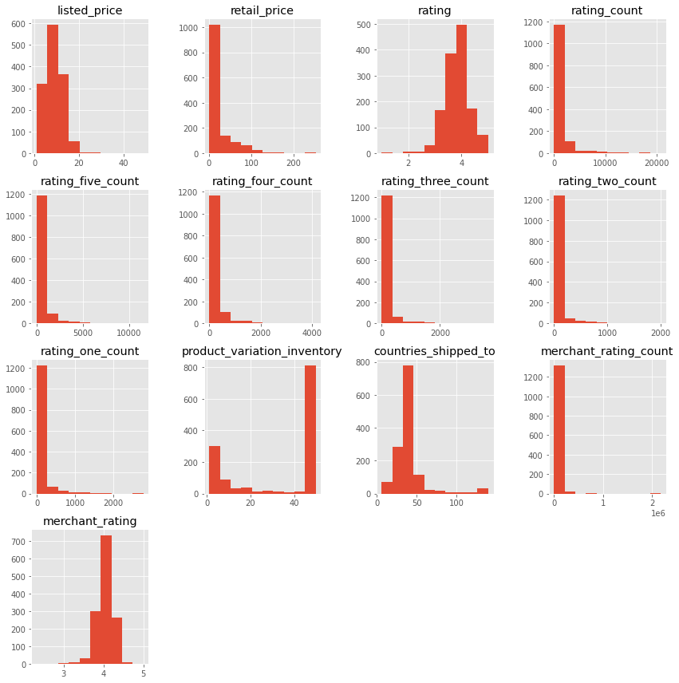

```python
hist = df[numerical_features].hist(figsize=(12, 12))

plt.tight_layout()
plt.show()
```

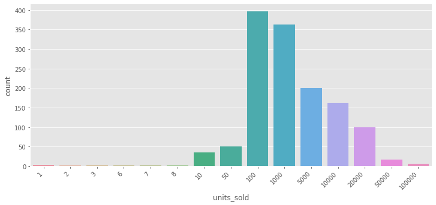

```python
# visualize the categorical features.

fig, ax = plt.subplots(figsize=(12, 5))

hist = sns.countplot(x='units_sold', data=df, order=sorted(df['units_sold'].unique()), ax=ax)

plt.xticks(rotation=45, ha='right')
plt.show()
```

```
Percent that the 'uses_ad_boosts' flag is True: 43.549590
Percent that the 'badge_product_quality' flag is True: 7.755406
Percent that the 'has_urgency_banner' flag is True: 27.293065
```

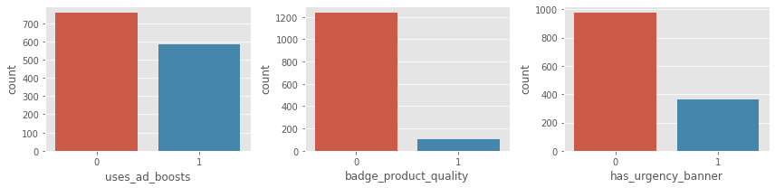

```python
# The features: `uses_ad_boosts`, `badge_product_quality`, and `has_urgency_banner` are binary.

fig = plt.figure(figsize=(12, 3))

boolean_features = ['uses_ad_boosts', 'badge_product_quality', 'has_urgency_banner']
for i in range(3):
    true_percentage = (df[boolean_features[i]].value_counts()[1] / len(df[boolean_features[i]])) * 100
    print("Percent that the '%s' flag is True: %f" % (boolean_features[i], true_percentage))

    fig.add_subplot(1, 3, i + 1)
    sns.countplot(df[boolean_features[i]])

plt.tight_layout()
plt.show()
```

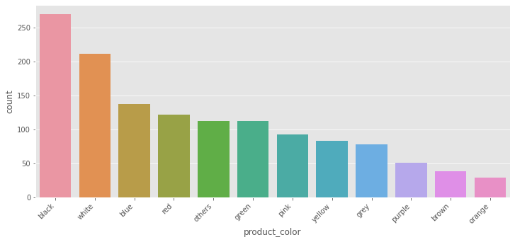

```python
# visualize the Product Colours.

fig, ax = plt.subplots(figsize=(12, 5))

sns.countplot(x='product_color', data=df, order=df['product_color'].value_counts().index, ax=ax)

ax.set(xlabel='product_color', ylabel='count')
plt.xticks(rotation=45, ha='right')

plt.show()
```

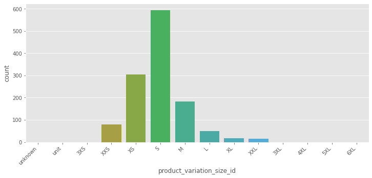

```python
# visualize the product_variation_size_id.


fig, ax = plt.subplots(figsize=(12, 5))

size_order = ['unknown', 'unit', '3XS', 'XXS', 'XS', 'S', 'M', 'L', 'XL', 'XXL', '3XL', '4XL', '5XL', '6XL']

sns.countplot(x='product_variation_size_id', data=df, order=size_order, ax=ax)

plt.xticks(rotation=45, ha='right')
plt.show()
```

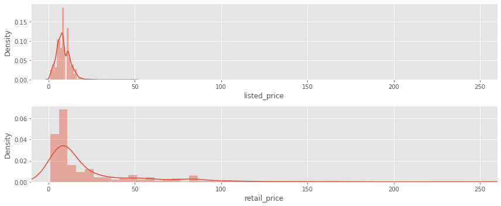

```python
# Visualizing product prices (prediction target).

fig = plt.figure(figsize=(12, 5))

fig.add_subplot(2,1,1)
ax1 = sns.distplot(df['listed_price'])
ax1.set_xlim(-10, 260)

fig.add_subplot(2,1,2)
ax2 = sns.distplot(df['retail_price'])
ax2.set_xlim(-10, 260)

plt.tight_layout()
```

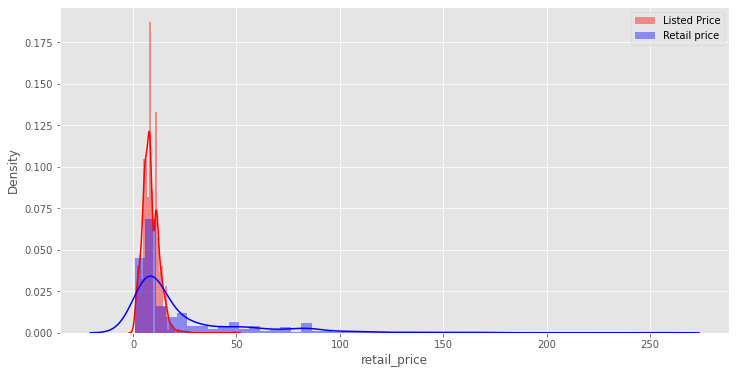

```python
plt.figure(figsize=(12,6))
sb.distplot(df['listed_price'], color='red', label='Listed Price')
sb.distplot(df['retail_price'], color='blue', label='Retail price')
plt.legend();
```

**The plot indicates a right skewed distribution but not very Clear**

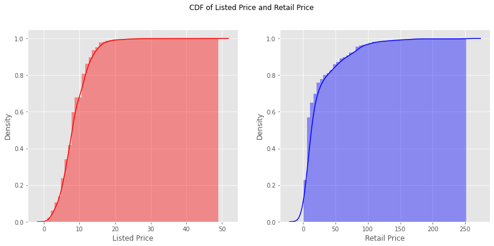

```python
kwargs = {'cumulative':True}
f, axes = plt.subplots(1,2, figsize=(14,6))
f.suptitle('CDF of Listed Price and Retail Price')
sb.distplot(df['listed_price'].values,kde_kws=kwargs, hist_kws=kwargs, color='red', label='Listed Price', ax=axes[0]);
sb.distplot(df['retail_price'].values,kde_kws=kwargs, hist_kws=kwargs, color='blue', label='Retail Price', ax=axes[1]);
axes[0].set(xlabel='Listed Price');
axes[1].set(xlabel='Retail Price');
```

CDFs are more useful inorder to visualize the data more efficiently.

CDF of price reveals that 97% of products are listed for less than aproximate price 19-20  
CDF of Price closely represents the CDF curve of Normal distribution which can be summarized efficiently except for the 3% data  
Incase of Retail price the distribution is not very much smooth and contains price gaps

```python
fig = go.Figure()
fig.add_trace(go.Box(x=df['retail_price'], name='Retail Price'))
fig.add_trace((go.Box(x=df['listed_price'], name='Listed Price')))
fig['layout']['title'] = 'Distribution of Listed Price and Retail Price'
fig.show()
```

[interactive chart not shown]

With Boxplots we can easily spot the outliers and quartiles

- The Upper fence of Price is at 18 i.e most of the data is priced less tha 18
- There an item wiht price of 49 i.e clearly an oulier as it is far away from the Inter Quartile Range (Q3 - Q1)
- Box plot of Retail price is much more spread out, there is huge difference of 195 between the upper fence and max data point

```python
#range for units sold
sorted(df['units_sold'].unique())
```

```
[1, 2, 3, 6, 7, 8, 10, 50, 100, 1000, 5000, 10000, 20000, 50000, 100000]
```

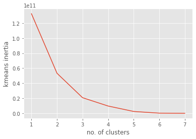

```python
from sklearn.cluster import KMeans

clusters = {}
for i in range(1,8):
    kmeans = KMeans(n_clusters=i).fit(df[['units_sold']])
    clusters[i] = kmeans.inertia_

plt.plot(list(clusters.keys()), list(clusters.values()));
plt.xlabel('no. of clusters');
plt.ylabel('kmeans inertia');
```

By performing clustering we can see that units_sold can be clustered in 3 categories (optimal) as the inertia curve smooths out after 3 clusters

```python
#order cluster method

def order_cluster(cluster_field_name, target_field_name,df,ascending):
    new_cluster_field_name = 'new_' + cluster_field_name
    df_new = df.groupby(cluster_field_name)[target_field_name].mean().reset_index()
    df_new = df_new.sort_values(by=target_field_name,ascending=ascending).reset_index(drop=True)
    df_new['index'] = df_new.index
    df_final = pd.merge(df,df_new[[cluster_field_name,'index']], on=cluster_field_name)
    df_final = df_final.drop([cluster_field_name],axis=1)
    df_final = df_final.rename(columns={"index":cluster_field_name})
    return df_final

df['units_sold_cluster'] = KMeans(n_clusters=3).fit(df[['units_sold']]).predict(df[['units_sold']])
df = order_cluster('units_sold_cluster','units_sold',df,True)
df.groupby(['units_sold_cluster'])['units_sold'].describe()
```

| units_sold_cluster | count | mean | std | min | 25% | 50% | 75% | max |
| --- | --- | --- | --- | --- | --- | --- | --- | --- |
| 0 | 1056.0 | 1330.027462 | 1820.903726 | 1.0 | 100.0 | 1000.0 | 1000.0 | 5000.0 |
| 1 | 262.0 | 13778.625954 | 4857.809727 | 10000.0 | 10000.0 | 10000.0 | 20000.0 | 20000.0 |
| 2 | 23.0 | 63043.478261 | 22448.887927 | 50000.0 | 50000.0 | 50000.0 | 75000.0 | 100000.0 |

now we have a clear picture of top selling, and price range of products

```python
px.scatter(df,x='units_sold',y='rating', color='units_sold_cluster', marginal_y ='box',title='Rating vs units sold')
```

[interactive chart not shown]

- Median for rating is 3.85 and the products in top selling cluster has rating between 3.35 to 4.1 seems very reasonable
- Rating is very important to determine the potential of product
- Still there are some products with 5 star rating yet unable to cross the 100-1000 unit sold line
- there are some really bad performing products with rating below 3

```python
px.scatter(df,x='rating',y='merchant_rating', color='units_sold_cluster', marginal_y ='box',title='Merchant Rating vs units sold', opacity=0.7)
```

[interactive chart not shown]

```python
px.scatter(df,x='rating', y='product_variation_inventory', color='units_sold_cluster', title='Product variation vs Rating')
```

[interactive chart not shown]

```python
fig = px.scatter(df,x='rating_count',y='rating', color='units_sold_cluster', title='Rating vs Rating count')
fig.add_trace(go.Scatter(x=np.ones((len(df)))*1103,y=df['rating'],name='Threshold 1'))
fig.add_trace(go.Scatter(x=np.ones((len(df)))*7773, y=df['rating'],name='Threshold 2'))
fig.update_layout(showlegend=False)
```

[interactive chart not shown]

**From above visualization we can conclude that products sold by merchants belonging to cluster 2 and 1 are Top selling,most liked and trusted by buyers**

- There's some kind of thresholding that can be done on rating and rating count to separate the 3 categories of products
- still there are few overlapping data points

```python
px.scatter(df,x='retail_price', y='listed_price',color='units_sold_cluster',marginal_y='box')
```

[interactive chart not shown]

Most of the top selling products seems be concentrated to the left where the price difference is much siginificant

```python
px.scatter(df, x='listed_price', y='shipping_option_price', color= 'units_sold_cluster', title='Shipping price vs Price')
```

[interactive chart not shown]

People always prefer paying less shipping charges we can see that most selling products has low shipping charges

### The distribution of prices and defining a successful product..

```python
print('Median of units sold is',df['units_sold'].median())
print('Mean of units sold is',df['units_sold'].mean())
df['units_sold'].value_counts()
```

```
Median of units sold is 1000.0
Mean of units sold is 4820.662938105891
```

```
100       396
1000      362
5000      200
10000     163
20000      99
50         50
10         36
50000      17
100000      6
1           3
8           2
7           2
3           2
2           2
6           1
Name: units_sold, dtype: int64
```

```python
def below_ten(units_sold):
    if units_sold < 10:
        return 10
    else:
        return units_sold
```

```python
df['units_sold'] = df['units_sold'].apply(below_ten)
df['units_sold'].value_counts()
```

```
100       396
1000      362
5000      200
10000     163
20000      99
50         50
10         48
50000      17
100000      6
Name: units_sold, dtype: int64
```

- The median is 1000 units sold. I will consider for those products with units sold over 1000 units as successful products.
- A quick look at the products with 100000 sales.

```python
df[df['units_sold'] == 100000]
```

|  | title_translated | listed_price | retail_price | units_sold | uses_ad_boosts | rating | rating_count | rating_five_count | rating_four_count | rating_three_count | rating_two_count | rating_one_count | badge_product_quality | tags | product_color | product_variation_size_id | product_variation_inventory | shipping_option_price | countries_shipped_to | has_urgency_banner | urgency_text | merchant_rating_count | merchant_rating | merchant_id | product_picture | product_id | units_sold_cluster |
| --- | --- | --- | --- | --- | --- | --- | --- | --- | --- | --- | --- | --- | --- | --- | --- | --- | --- | --- | --- | --- | --- | --- | --- | --- | --- | --- | --- |
| 1319 | 2018 New Fashion Women's Tops Sexy Strappy Sle... | 5.00 | 25 | 100000 | 1 | 3.83 | 17980 | 8290.0 | 3483.0 | 2951.0 | 1410.0 | 1846.0 | 0 | ('blouse', 'plus size', 'lace', 'lace top', 't... | white | S | 50 | 1 | 41 | 1 | QuantityLimited | 139223 | 3.933581 | 5708773c3c02161b3f8c7900 | https://contestimg.wish.com/api/webimage/5b07a... | 5b07a7c6e997b33c6f9947da | 2 |
| 1322 | Women Stretchy Camisole Spaghetti Strap Long T... | 5.77 | 48 | 100000 | 0 | 4.10 | 20744 | 11184.0 | 4152.0 | 2919.0 | 1174.0 | 1315.0 | 0 | ('mini', 'strapless dress', 'spaghetti strap',... | black | XS | 50 | 2 | 46 | 0 | noText | 330405 | 4.067348 | 53f2beb39020ee03566d6e18 | https://contestimg.wish.com/api/webimage/544b0... | 544b079d1280fa28eee9b380 | 2 |
| 1323 | New Aeeival Women Clothing Long Sleeve Autumn ... | 8.00 | 7 | 100000 | 1 | 3.76 | 11062 | 4663.0 | 2418.0 | 1868.0 | 842.0 | 1271.0 | 0 | ('roupas femininas', 'womens dresses', 'lace',... | green | M | 10 | 2 | 38 | 0 | noText | 108048 | 4.052504 | 5417aada4ad3ab27e954b76c | https://contestimg.wish.com/api/webimage/54bdf... | 54bdf18039b8c045f118936a | 2 |
| 1324 | Womens Summer Red White and Blue Chiffon Short... | 5.00 | 33 | 100000 | 0 | 3.98 | 13789 | 6862.0 | 2836.0 | 2131.0 | 901.0 | 1059.0 | 0 | ('summer', 'plus size', 'cotton t shirt', 'chi... | orange | S | 50 | 1 | 41 | 0 | noText | 366898 | 4.036081 | 53082ea15aefb07dfe1f2a4f | https://contestimg.wish.com/api/webimage/53897... | 53897eeeafddf70c91af1cda | 2 |
| 1335 | Women Lace Short Sleeve Long Tops Blouse Shirt... | 7.00 | 22 | 100000 | 1 | 3.82 | 11913 | 5355.0 | 2430.0 | 1974.0 | 960.0 | 1194.0 | 0 | ('blouse', 'fashion', 'shirt', 'boho', 'tops',... | others | S | 50 | 2 | 46 | 0 | noText | 320031 | 4.218866 | 5357bcf2bb72c5504882e889 | https://contestimg.wish.com/api/webimage/567cb... | 567cb0925ff12c4829f07dfb | 2 |
| 1337 | Women's Summer Sexy Sleeveless Turtleneck Mini... | 5.67 | 19 | 100000 | 0 | 3.53 | 18393 | 6769.0 | 3404.0 | 3658.0 | 2003.0 | 2559.0 | 0 | ('slim dress', 'mini', 'elegant', 'dress', 'mi... | grey | M | 50 | 1 | 37 | 1 | QuantityLimited | 19248 | 3.889131 | 570f3a713a698c14278bb51e | https://contestimg.wish.com/api/webimage/571ad... | 571adeab62cce546f1a46bc0 | 2 |

```python
# A simple function to create a new label 'is_successful':A simple function to create a new label 'is_successful':

def is_successful(units_sold):
    if units_sold > 1000:
        return 1
    else:
        return 0
```

```
Percent of successful products:  36.16703952274422
```

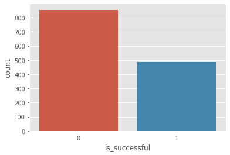

```python
df['is_successful'] = df['units_sold'].apply(is_successful)
#df['is_successful'] = df['units_sold'].apply(is_successful).astype('category')
print('Percent of successful products: ', df['is_successful'].value_counts()[1] / len(df['is_successful'])*100)
sb.countplot(data=df, x='is_successful')
plt.show()
```

### The use of ad boosts to boost the success..

There is an almost equal use of ad boosts by the products.

```python
print('Percent of products using ad boosts: ', df['uses_ad_boosts'].value_counts()[1] / len(df['uses_ad_boosts'])*100)
```

```
Percent of products using ad boosts:  43.54958985831469
```

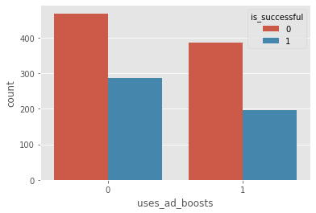

```python
sb.countplot(data=df, x='uses_ad_boosts', hue='is_successful')
```

```python
pd.crosstab(df['uses_ad_boosts'], df['is_successful'])
```

| is_successful uses_ad_boosts | 0 | 1 |
| --- | --- | --- |
| 0 | 469 | 288 |
| 1 | 387 | 197 |

### Higher ratings means higher units sold?

```python
df['rating']
```

```
0       3.76
1       3.57
2       4.03
3       3.10
4       5.00
        ...
1336    3.91
1337    3.53
1338    4.01
1339    4.01
1340    3.60
Name: rating, Length: 1341, dtype: float64
```

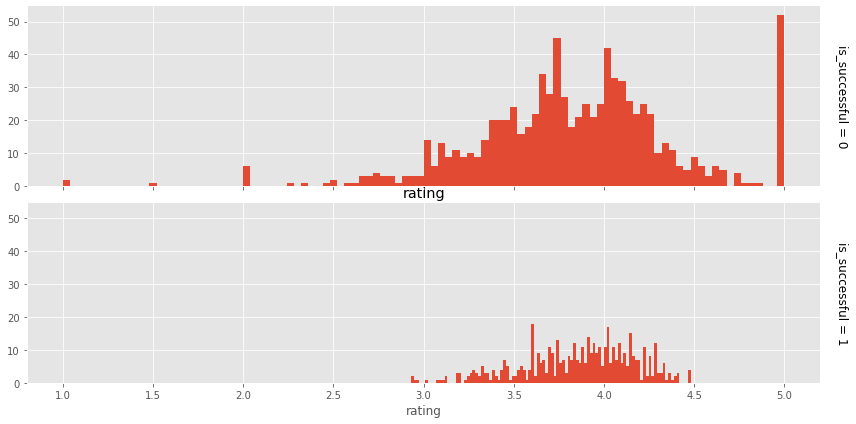

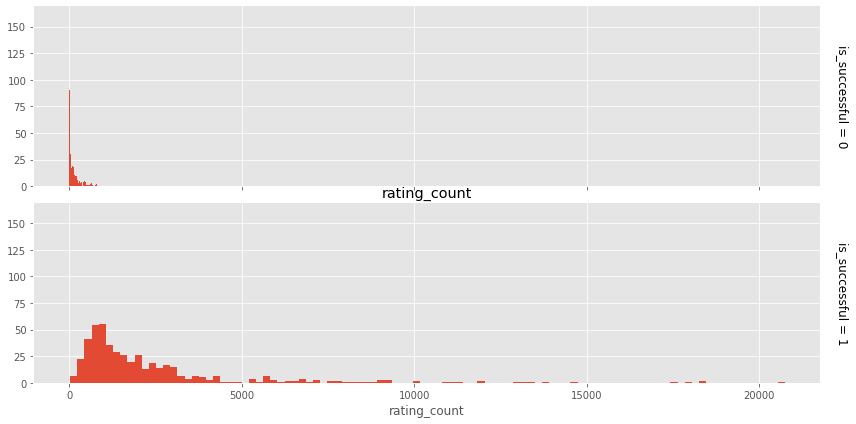

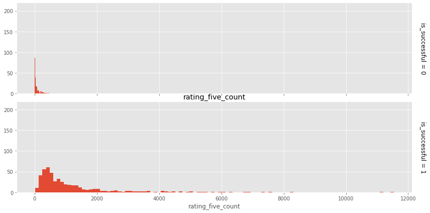

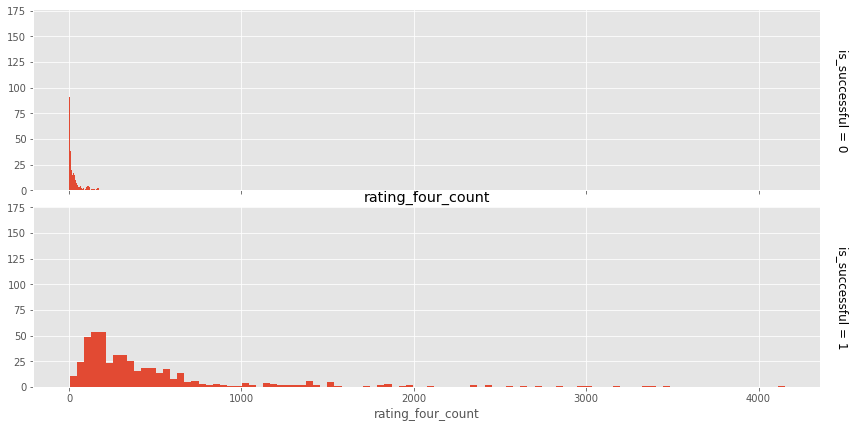

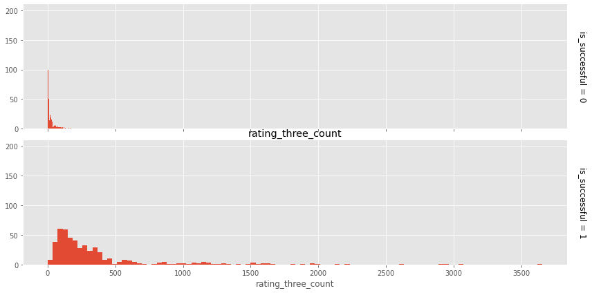

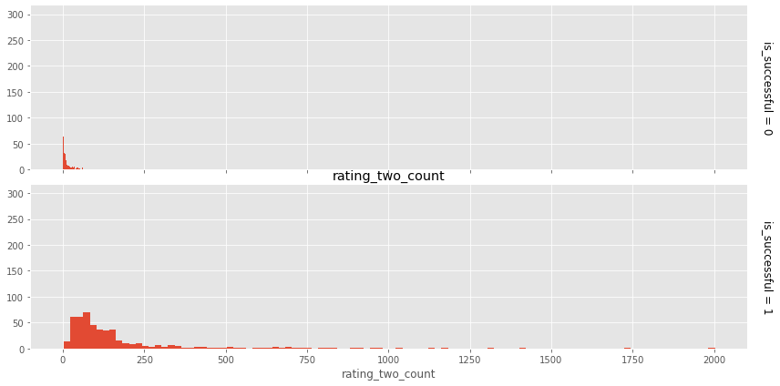

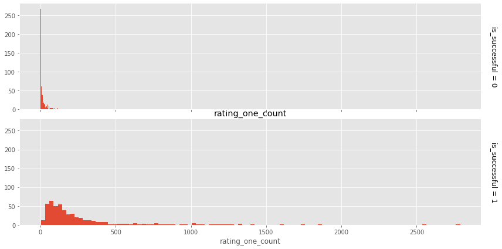

```python
ratings_column = ['rating', 'rating_count',
       'rating_five_count', 'rating_four_count', 'rating_three_count',
       'rating_two_count', 'rating_one_count']

for column in ratings_column:
    g = sb.FacetGrid(df, row='is_successful', margin_titles=True, aspect=4, height=3)
    g.map(plt.hist, column, bins=100)
    plt.title(column)
    plt.show()
```

```python
df.groupby('is_successful').mean()[ratings_column]
```

| is_successful | rating | rating_count | rating_five_count | rating_four_count | rating_three_count | rating_two_count | rating_one_count |
| --- | --- | --- | --- | --- | --- | --- | --- |
| 0 | 3.829603 | 136.151869 | 65.349299 | 26.147196 | 19.109813 | 9.344626 | 16.200935 |
| 1 | 3.858701 | 2474.486598 | 1196.740206 | 486.369072 | 365.517526 | 172.329897 | 253.529897 |

```python
df.groupby('units_sold').mean()[ratings_column]
```

| units_sold | rating | rating_count | rating_five_count | rating_four_count | rating_three_count | rating_two_count | rating_one_count |
| --- | --- | --- | --- | --- | --- | --- | --- |
| 10 | 4.388750 | 1.479167 | 0.625000 | 0.229167 | 0.229167 | 0.187500 | 0.208333 |
| 50 | 3.977600 | 5.920000 | 3.000000 | 1.260000 | 0.720000 | 0.400000 | 0.540000 |
| 100 | 3.752626 | 34.568182 | 16.002525 | 6.585859 | 4.823232 | 2.492424 | 4.664141 |
| 1000 | 3.819227 | 283.121547 | 136.524862 | 54.419890 | 39.781768 | 19.290055 | 33.104972 |
| 5000 | 3.818900 | 882.220000 | 421.290000 | 168.720000 | 127.325000 | 62.415000 | 102.470000 |
| 10000 | 3.898282 | 1847.257669 | 922.674847 | 365.361963 | 258.582822 | 119.171779 | 181.466258 |
| 20000 | 3.867576 | 4507.626263 | 2161.181818 | 889.747475 | 673.959596 | 317.393939 | 465.343434 |
| 50000 | 3.903529 | 10731.941176 | 5216.764706 | 2104.882353 | 1614.058824 | 762.352941 | 1033.882353 |
| 100000 | 3.836667 | 15646.833333 | 7187.166667 | 3120.500000 | 2583.500000 | 1215.000000 | 1540.666667 |

Successful products have more ratings. This is expected as units sold is higher so rating is also higher. However, if I am building a model, I don't think it would be a good idea to keep this column as the huge number of ratings must be the result of higher units sold.

# Some conclusions